# Práctica - Análisis de Redes Sociales - MDSF

## Análisis de comunidades de la componente conexa mayor (1,5 puntos)

```r
### Inserta aqui tu codigo

# Algoritmo de Louvain: algoritmo de particionamiento de grafos que busca maximizar la modularidad de la red al agrupar los nodos en comunidades densamente conectadas.
# La resolución determina el nivel de escala al que se forman las comunidades.
louvain_clusters <- cluster_louvain(g2,  weights = NULL, resolution = 0.3)


# Calcular la modularidad de ambos métodos
modularity_louvain <- modularity(louvain_clusters)

# print modularidad
print(glue("La modularidad del algoritmo de Louvain es de {round(modularity_louvain,3)}"))
```

[output not shown]

```
## La modularidad del algoritmo de Louvain es de 0.711
```

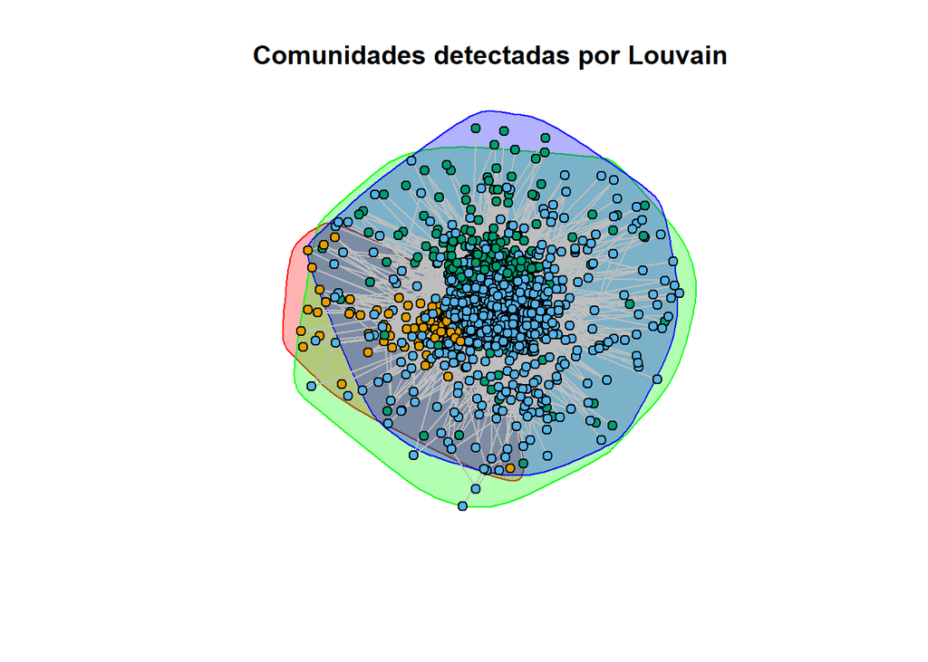

```r
# Configurar el tamaño y color de los nodos
color_nodos <- rainbow(max(membership(louvain_clusters)))

# Configurar la disposición del grafo
layout <- layout_with_fr(g2)

# Visualización mejorada
plot(
  louvain_clusters, g2,
  layout = layout,
  vertex.size = 5,
  vertex.color = color_nodos,
  vertex.label = NA,
  edge.color = "gray",
  main = "Comunidades detectadas por Louvain"
)
```

## Visualización del grafo por comunidades de la componente conexa mayor (1,5 puntos)

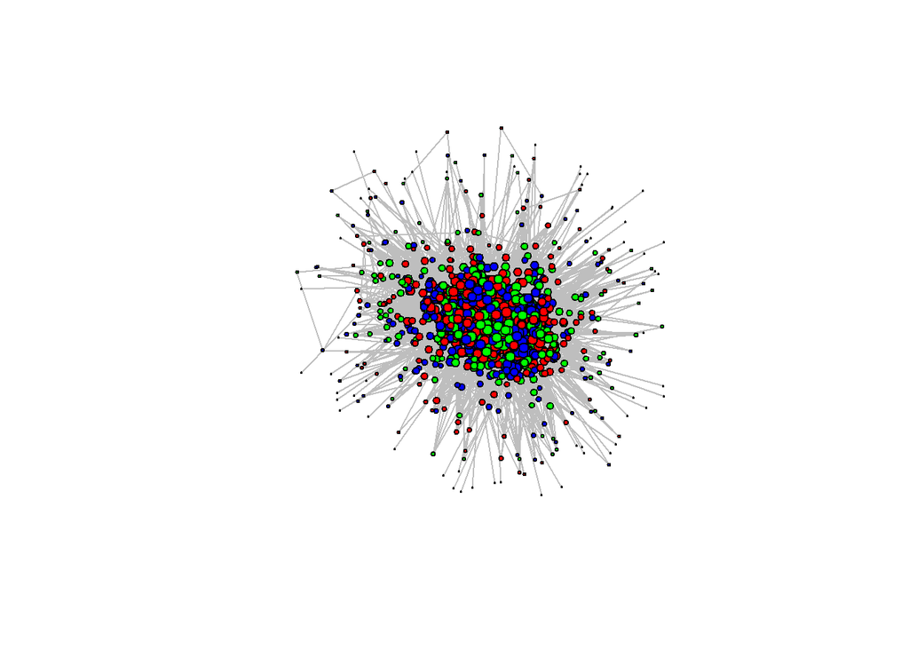

```r
### Inserta aqui tu codigo
ll <- layout.fruchterman.reingold(g2)

plot(g2, vertex.label= NA,
         vertex.color = color_nodos,
         layout=ll,
         edge.width = 1,
         edge.color = "gray",
         vertex.size = (log(degree(g2))+1))
```

## Difundiendo un rumor (o un virus) en la componente conexa mayor (4 puntos)

Este apartado es el que más peso en la práctica tiene. Vamos a implementar un modelo epidemiológico sobre el grafo que, típicamente, se utiliza para simular escenarios de difusión de enfermedades pero también en contextos como la distribución de rumoeres e información. Vamos a implementar un modelo SIR que se caracteriza por tener los siguientes parámetros:

- Número de nodos iniciales infectados en el momento t=0 (N).
- Beta: probabilidad de contagio de un nodo infectado (I) a un nodo susceptible de serlo (S)
- Gamma: probabilidad de que un nodo infectado (I) se recupere en momenteo actual (R). Los nodos en estado (R) no son susceptibles y permanecen en este estado infinitamente.

Se pide desarrollar una función que tenga como parámetros los tres valores anteriores y un cuarto que sea un grafo que, en nuestro caso, será la componente conexa mayor del grafo original de esta práctica. Dicha función simulará el proceso SIR:

- En t=0, se seleccionan N nodos al azar, que pasarán a estado infectado.
- En t=1, se podrán contagiar con probabilidad Beta nodos que tienen un vecino infectado; OJO: si un nodo en estado S tiene varios vecinos en estado I tiene más probabilidad de infectarse ya que cada vecino tendrá un intento de infectarle.
- Se repite el paso anterior sucesivamente, hasta que no vemos infectados nuevos durante, al menos, 3 iteraciones.

Se pide ejecutar una simulación para tres o cuatro valores del parámetro beta (N y gamma pueden ser fijos en estas simulaciones) de este proceso de manera que se pueda visualizar:

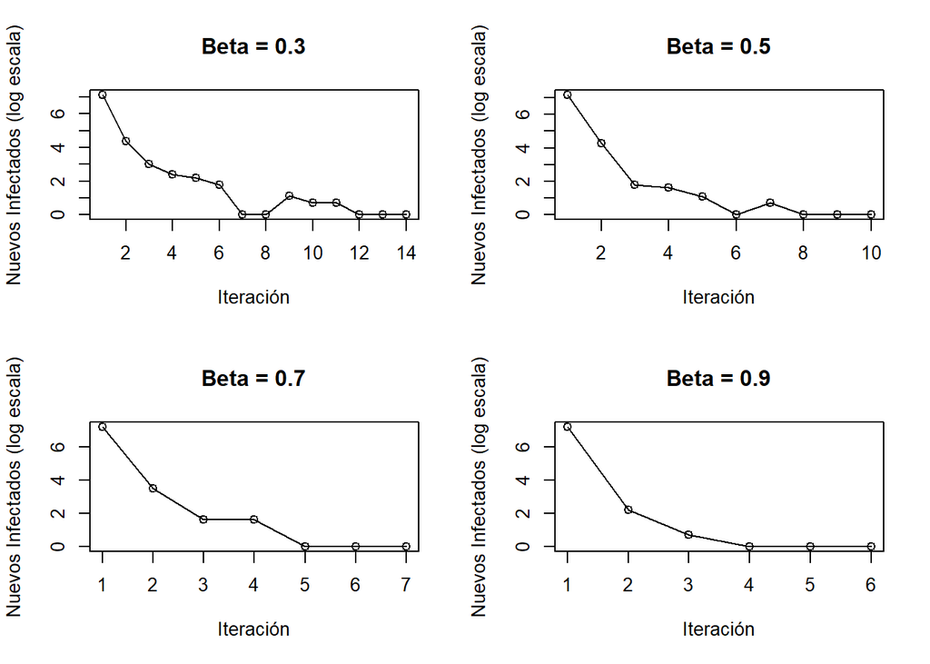

```r
library(igraph)

# Función para simular el modelo SIR en un grafo
simular_SIR <- function(N, beta, gamma, graph) {
  node_states <- rep(0, vcount(graph))  # Todos los nodos empiezan como susceptibles
  initial_infected <- sample(1:vcount(graph), N)
  node_states[initial_infected] <- 1

  new_infected <- vector()
  contagion_graphs <- list()
  contagion_graph <- make_empty_graph(vcount(graph), directed = TRUE)

  # Iteración 0 con los primeros contagiados
  contagion_graphs[[1]] <- list(
    contagion_graph = contagion_graph,
    node_states = node_states
  )

  stop_not_infected <- 0
  iter <- 2  # Empezar la iteración en 2 para que la 1 sea la inicial con contagiados

  while (stop_not_infected < 3) {
    current_new_infected <- 0

    for (node in 1:vcount(graph)) {
      if (node_states[node] == 0) {
        neighbors <- neighbors(graph, node)
        if (length(neighbors) > 0 && any(node_states[neighbors] == 1)) {
          for (neighbor in neighbors) {
            if (node_states[neighbor] == 1 && runif(1) < beta) {
              node_states[node] <- 1
              current_new_infected <- current_new_infected + 1
              contagion_graph <- add_edges(contagion_graph, c(neighbor, node))
              break
            }
          }
        }
      } else if (node_states[node] == 1) {
        if (runif(1) < gamma) {
          node_states[node] <- 2
        }
      }
    }

    new_infected <- c(new_infected, current_new_infected)
    contagion_graphs[[iter]] <- list(
      contagion_graph = contagion_graph,
      node_states = node_states
    )

    if (current_new_infected == 0) {
      stop_not_infected <- stop_not_infected + 1
    } else {
      stop_not_infected <- 0
    }

    iter <- iter + 1
  }

  list(
    new_infected = new_infected,
    contagion_graphs = contagion_graphs,
    initial_infected = initial_infected
  )
}

# Parámetros de la simulación
N <- 5
betas <- c(0.3, 0.5, 0.7, 0.9)
gamma <- 0.1

# Almacenar los resultados
results <- lapply(betas, function(beta) {
  list(beta = beta, result = simular_SIR(N, beta, gamma, g2))
})

# Curva de nuevos infectados en escala logarítmica
par(mfrow=c(2,2))
for (i in 1:length(results)) {
  new_infected <- results[[i]]$result$new_infected
  plot(log1p(new_infected), type="o", main=paste("Beta =", results[[i]]$beta),
       xlab="Iteración", ylab="Nuevos Infectados (log escala)")
}
```

```r
# Crear una carpeta para las imágenes
dir.create("img", showWarnings = FALSE)

# Grafo de contagios en cada iteración
for (i in 1:length(results)) {
  beta <- results[[i]]$beta
  contagion_graphs <- results[[i]]$result$contagion_graphs
  initial_infected <- results[[i]]$result$initial_infected
  for (j in 1:(length(contagion_graphs))) {  # Mostrar hasta 3 iteraciones por beta
    img <- 1

    contagion_graph <- contagion_graphs[[j]]$contagion_graph
    node_states <- contagion_graphs[[j]]$node_states

    V(contagion_graph)$color <- ifelse(node_states == 1, "red",
                                       ifelse(node_states == 2, "green", "white"))
    V(contagion_graph)$color[initial_infected] <- "blue"

        # Guardar la imagen lo mejor será guardarlo como 1 y ya
    filename <- paste("img/",img ,".png", sep="")
    png(filename, width = 1200, height = 800)
    plot(contagion_graph, main=paste("Beta =", beta, "Iteración =", j - 1),
         vertex.label=NA, vertex.size=5, edge.arrow.size=0.5, layout = layout)
    dev.off()

    img <- img + 1
    }
}
```

[output not shown]

```r
# Cargar las bibliotecas necesarias
library(magick)
library(lubridate)
library(knitr)
```

```r
# Crear una lista de nombres de archivos de las imágenes
file_names <- list.files(path = "img/", full.names = TRUE)
file_names <- file_names[order(file_names)]  # Ordenar los nombres de archivos

# Crear el GIF
gif_filename <- "resultados.gif"
image_sequence <- image_read(file_names)
image_write(image_sequence, gif_filename)
# Incluir el GIF en el documento
#knitr::include_graphics(paste0(gif_filename, "?", lubridate::now()))
```